# Meta analysis

2023-03-23

> [*Back to content page*](https://flatter11.github.io/r.studio/)

# Tutorial 3 – Meta analysis

**Fish consumption and depression**

It has been proposed that dietary factors can be associated with risk of depression. Studies have investigated the association between fish consumption and risk of depression, but the issue is still controversial. A systematic review and meta-analysis of observational study may help to gather the best evidence for the association. After a systematic review, 16 studies were found suitable for obtaining a pooled estimated effect of high fish consumption. Some of these studies provided sex or country-specific estimates. The data was saved in ‘fishconsumption.csv’ (extracted from Li et al., JECH, 2016), with the following variables

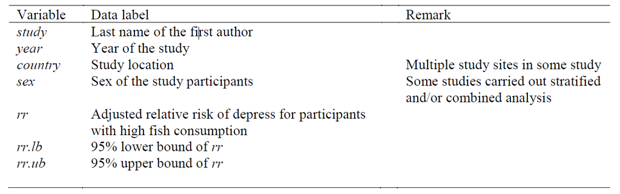

## 1. Read the dataset

Read the dataset into R and study the dataset.

```r
fish <- read.csv("Folder/fishconsumption.csv")
```

## 2. Fixed effect model

Fit a fixed effects model to estimate overall effect and the associated 95% CI of high fish consumption. (Use the combined estimates for study with both combined and sex-specific estimates)

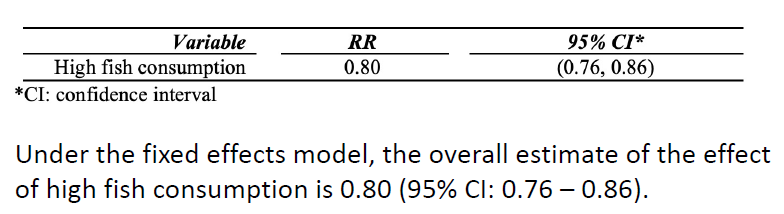

```r
# mark stratified analysis (data are duplicated)
fish$strat <- 0
fish$strat[c(21, 22, 24, 25)] <- 1

#Find se
fish$logrr <- log(fish$rr)
fish$logrr.se <- (log(fish$rr.ub) - log(fish$rr.lb)) / (2*1.96)

#Fixed effect model
require(metafor)
fish.fe <- rma(yi=logrr, sei=logrr.se, slab=study, method="FE", data=fish, subset=strat==0)
fish.fe
round(with(fish.fe, exp(c(b, ci.lb, ci.ub))),3) #estimate and 95%CI
```

## 3. Reproduce manually

Try to reproduce the above results using inverse variance weighting method.

$(\hat\theta =Σ_i𝑤_i𝑌_i/Σ_i𝑤_𝑖\space,\space var(\hat \theta)=1/Σ_i𝑤_𝑖)$

```r
# Estimate
estimate.log <- with(fish[fish$strat==0,], sum(logrr/logrr.se^2)/sum(1/logrr.se^2))
# 95%CI
var.log <- with(fish[fish$strat==0,],1/sum(1/logrr.se^2))
# same result as question 2
exp(c(estimate.log, estimate.log + c(-1,1)*1.96*sqrt(var.log)))
```

## 4. Heterogeneity

Assess the heterogeneity between studies. Do you think a fixed effects model is appropriate?

```r
# Q-statistics and I2 (M1)
summary(fish.fe)
# Q-statistics and I2 (M2)
Q <- fish.fe$QE
I2 <- (Q-(fish.fe$k-1))/Q * 100
```

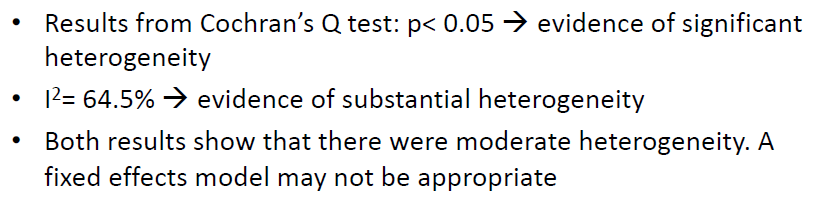

## 5. Random effect model

Fit a random effects model to estimate overall effect and the associated 95% CI of high fish consumption.

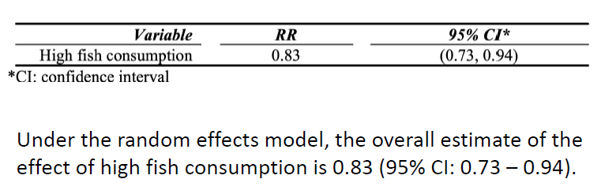

```r
fish.re <- rma(yi=logrr, se=logrr.se, slab=study, data=fish, subset=strat==0)
round(with(fish.re, exp(c(b, ci.lb, ci.ub))),3)
```

## 6. Forest plot

Produce a forest plot of the relative risks based on your final model

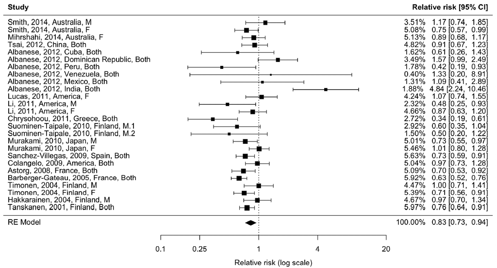

```r
## Forest plot based on the random effects model
forest(fish.re, transf=exp, refline=1) #exp each data
forest(fish.re, atransf=exp, refline=0,at=log(c(0.1,0.25,1,4,20)), showweights=T) #exp x axis (note atransf, at=log)

## To have more information shown in the plot
fish.re <- rma(yi=logrr, sei=se.logrr, slab=paste(study, year, country, sex, sep=", "), method="REML", data=fish, subset=strat==0) #note slab
forest(fish.re, atransf=exp, refline=0, at=log(c(0.1,0.25,1,4,20)), xlim=c(-6,5.5), showweights=T, xlab="Relative risk (log scale)") #note xlim, xlab
# add labels; pos = 2 and 4 indicate positions to the left and right of specified (x,y) coordinates; x = -6 and 5.5 following the xlim set in previous code
text(-6, 28, "Study", pos=4, font=2)
text(5.5, 28, "Relative risk [95% CI]", pos=2, font=2)
```

## 7. Publication bias

Assess if there is evidence of publication bias.

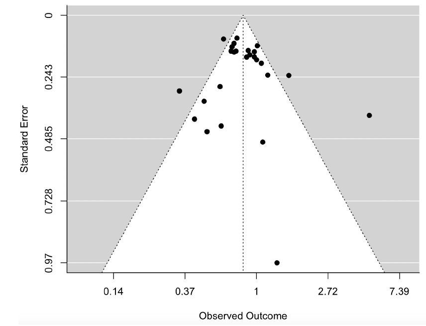

```r
# funnel plot; note yaxis="ni" to change y-axis to sample sizes
funnel(fish.re, atransf=exp)
# Egger's test
regtest(fish.re)
## No obvious asymmetry can be seen from the funnel plot, and there was no strong evidence of asymmetry from Egger’s test (p-val=0.7733 > 0.05). No evidence of publication bias.
```

## 8. Meta-regression

Suppose we like to test if there is heterogeneity due to difference in sex and study year. Perform a meta-regression on sex. (hint: in rma function, include moderator in yi = effect ~ moderator)

```r
## meta regression on sex
fish$sex.spec <- 1*(fish$sex!="Both") #! to remove all study with sex=both
fish.sex <- fish[fish$sex.spec==1,]
fish.re.sex <- rma(yi=logrr~sex, sei=logrr.se, slab=study, method = "REML", data=fish.sex)
fish.re.sex
# Insignificant result coz p-val = 0.6695 > 0.05

## meta regression on year
fish.re.year <- rma(yi=logrr~year, sei=logrr.se, slab=study, method = "REML", data=fish, subset=strat==0) #note: use original dataset and set strata
fish.re.year
# Insignificant result coz p-val = 0.3691 > 0.05

## • Estimate of sex = -0.0439, p-value = 0.670 > 0.05
## • Estimate of year = 0.0155, p-value = 0.369 > 0.05
## • Sex and year cannot explain the heterogeneity
```

## 9. Exclude 2 study

Suppose after the quality assessment, it was found that Smith et al. 2014 and Colangelo et al 2009 have relatively lower quality. Would that affect the overall estimates qualitatively? (exclude 2 studies)

```r
## sensitivity analysis
fish$lq <- 0 # define low quality variable
fish$lq[fish$study=="Smith"|fish$study=="Colangelo"] <- 1
fish.re.sen <- rma(yi=logrr, sei=logrr.se, slab=study, method="REML", data=fish, subset=(strat==0 & lq==0)) # note subset set lq==0

## compare the original estimate vs estimate from sensitivity analysis
with(fish.re, exp(c(b, ci.lb, ci.ub)))
# [1] 0.8295321 0.7326719 0.9391973
with(fish.re.sen, exp(c(b, ci.lb, ci.ub)))
# [1] 0.8158938 0.7031912 0.9466595

## There is not much difference between the estimate and CI in main analysis and
# sensitivity analysis, showing that studies with lower quality would not affect
# the overall estimates qualitatively.
```

## 10. Leave-one-out

Carry a leave-one-out sensitivity analysis to assess the impact of study heterogeneity on the overall estimate. (hint: R function: leave1out())

Leave-one-out method: for K data points, remove data point 1, 2, …, K to perform K analyses to assess impact of individual data.

```r
## leave one out sensitivity analysis
leave1out(fish.re, transf=exp)
# The estimates from the leave-one-out sensitivity analysis were
# similar. The overall estimate is not sensitive to any single study.
```

## 11. Conclusion

Draw a conclusion for the meta analysis based on the above results

Present 2 points:

1. Estimate/assoication
2. Sensitivity analysis/model u used

High fish consumption is associated with lower risk of depression (RR = 0.83, 95% CI = 0.73 to 0.94). The result is not sensitive to studies which may have lower quality and individual study with leave-one-out method. (using random effect model)

## 12. Trim and fill

Carry out a trim and fill sensitivity analysis for publication bias. (hint: R function: trimfill()). Suppose the study by Albanese et al. was not included?

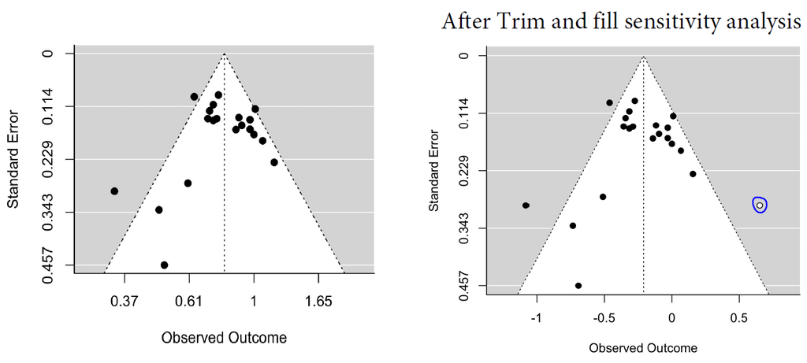

```r
## Exclude albanese study
fish.cut <- fish[fish$study!="Albanese",]
fish.cut.re <- rma(yi=logrr, sei=logrr.se, slab=paste(study, year, country, sex, sep=", "), method="REML", data=fish.cut,subset=strat==0)
funnel(fish.cut.re, atransf=exp)
# Egger's test
regtest(fish.cut.re)
# No obvious asymmetry can be seen from the funnel plot, and there was no strong
# evidence of asymmetry from Egger’s test (p-val = 0.2163 > 0.05). No evidence of publication bias.

## Trim and fill sensitivity analysis
fish.cut.tf <- trimfill(fish.cut.re)
with(fish.cut.tf, exp(c(b, ci.lb, ci.ub)))
# [1] 0.8108338 0.7350417 0.8944411 # very close to previous estimate
funnel(fish.cut.tf)

## The estimated intervention effect ‘adjusted’ for the publication bias is 0.81,
# similar to our original estimate from random effect model (0.83).
# [No evidence of publication bias so it is expected to have similar estimates
# from trim-and-fill analysis].
```